# hw03

Wade

September 30, 2017

In this assignment, I will be using dplyr and ggplot2 to explore the gapminder dataset.

```r
suppressPackageStartupMessages(library(gapminder))
suppressPackageStartupMessages(library(tidyverse))
```

I have a list of tasks to choose from. I will do at least 3 of them.

#### Task 1

First, let’s look at how life expectancy changes on different continents.

```r
class(gapminder$continent)
```

```
## [1] "factor"
```

```r
class(gapminder$lifeExp)
```

```
## [1] "numeric"
```

It’s always good to check the class of the variables you are working with before you get started.

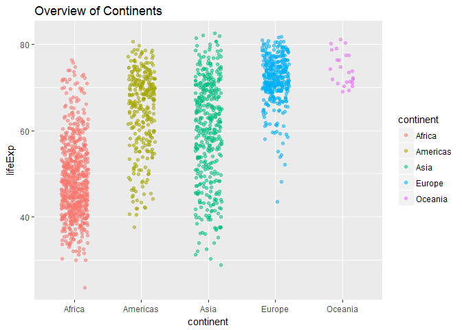

```r
g<-ggplot(gapminder, aes(x=continent, y=lifeExp))
g  + geom_jitter(alpha=.5, aes(color=continent), position=position_jitter(width=.2)) +
  labs(title="Overview of Continents")
```

This is a good graph showing an overview of life expectancies across each continent. But is there more information that we can glean from this dataset to answer our original question?

I would like to know how the average life expectancy for each continent has changed over time.

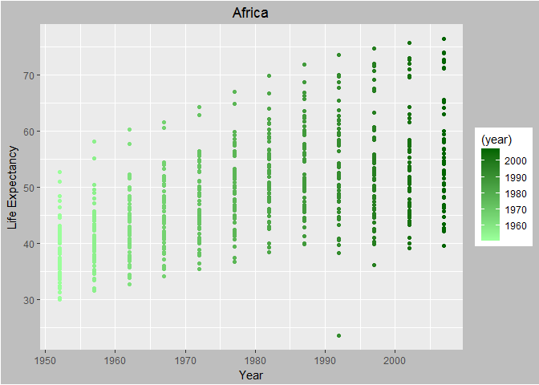

```r
filter(gapminder, continent=="Africa") %>%
  arrange(year) %>%
  ggplot(aes(lifeExp, year, color=(year))) +
  coord_flip()+
  geom_point()+
  scale_color_gradient(low="palegreen1", high="darkgreen")+
   theme(plot.background = element_rect(fill = 'grey'),plot.title = element_text(hjust = 0.5))+ # Center the title
  labs(title="Africa", x= "Life Expectancy", y= "Year") #These are actually switched because I originally used the coord_flip function
```

This plot reveals something interesting. There was one entry that yielded a far lower life expectancy in Africa than all of the others. This may correspond to the **Rwandan genocide** in 1994.

Let’s generate comparable graphs for each of the other continents.

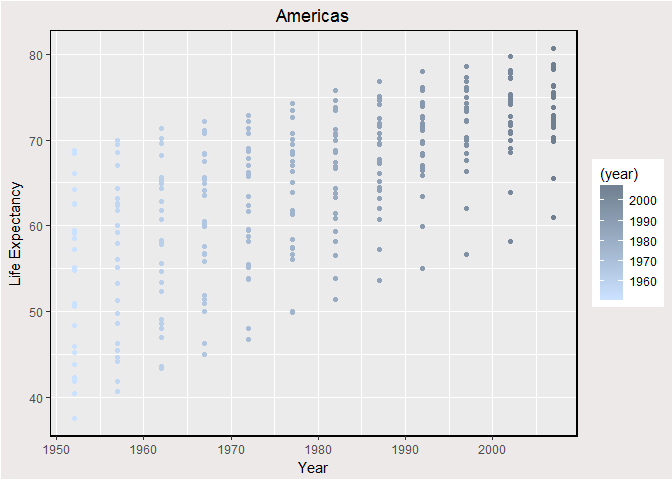

```r
filter(gapminder, continent=="Americas") %>%
  arrange(year) %>%
  ggplot(aes(lifeExp, year, color=(year))) +
  coord_flip()+
  geom_point()+
  scale_color_gradient(low="lightsteelblue1", high="slategrey")+
   theme(plot.background = element_rect(fill = 'snow2'),plot.title = element_text(hjust = 0.5), panel.border = element_rect(colour = "black", fill=NA, size=1))+ #added a border
  labs(title="Americas", x= "Life Expectancy", y= "Year")
```

In the Americas, there is a constant, steady increase in life expectancy. This presents real issues to the social security program, which was started in 1935 when the average life expectancy was much lower.

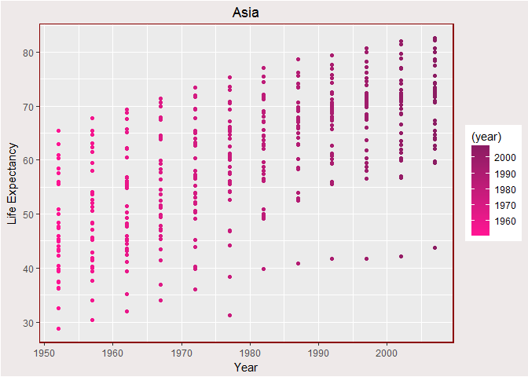

```r
filter(gapminder, continent=="Asia") %>%
  arrange(year) %>%
  ggplot(aes(lifeExp, year, color=(year))) +
  coord_flip()+
  geom_point()+
  scale_color_gradient(low="deeppink", high="maroon4")+
   theme(plot.background = element_rect(fill = 'snow2'),plot.title = element_text(hjust = 0.5), panel.border = element_rect(colour = "darkred", fill=NA, size=1))+
  labs(title="Asia", x= "Life Expectancy", y= "Year")
```

Some of the countries in Asia appear to have had consistently low life expectancies compared to the rest of the continent. After some searching, I found that Cambodia had a civil war in the 1970s.

```r
cam<-filter(gapminder, country=="Cambodia")
knitr::kable(head(cam, format = "markdown"))
```

| country | continent | year | lifeExp | pop | gdpPercap |
| --- | --- | --- | --- | --- | --- |
| Cambodia | Asia | 1952 | 39.417 | 4693836 | 368.4693 |
| Cambodia | Asia | 1957 | 41.366 | 5322536 | 434.0383 |
| Cambodia | Asia | 1962 | 43.415 | 6083619 | 496.9136 |
| Cambodia | Asia | 1967 | 45.415 | 6960067 | 523.4323 |
| Cambodia | Asia | 1972 | 40.317 | 7450606 | 421.6240 |
| Cambodia | Asia | 1977 | 31.220 | 6978607 | 524.9722 |

Here we can see a large drop from their 1972 life expecancy to their 1977 life expectancy corresponding to a genocide of between 1.5-3 million people.

On a lighter note, R only offers 4 shades of maroon. Now we know how Maroon 5 got its name!

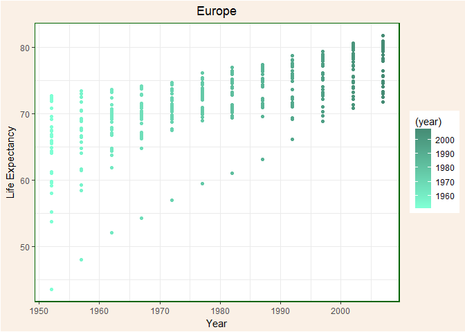

```r
filter(gapminder, continent=="Europe") %>%
  arrange(year) %>%
  ggplot(aes(lifeExp, year, color=(year))) +
  coord_flip()+
  geom_point()+
  scale_color_gradient(low="aquamarine", high="aquamarine4")+
  labs(title="Europe", x= "Life Expectancy", y= "Year")+
  theme_bw()+
  theme(plot.background = element_rect(fill = 'linen'),plot.title = element_text(hjust = 0.5), panel.border = element_rect(colour = "darkgreen", fill=NA, size=1))
```

It looks like one country in Europe has trailed far behind the others. I wonder which one it is…?

```r
eur<-filter(gapminder, continent=="Europe") %>%
  arrange(lifeExp)
knitr::kable(head(eur, n=20) %>% arrange(year), format = "markdown")
```

| country | continent | year | lifeExp | pop | gdpPercap |
| --- | --- | --- | --- | --- | --- |
| Turkey | Europe | 1952 | 43.585 | 22235677 | 1969.1010 |
| Bosnia and Herzegovina | Europe | 1952 | 53.820 | 2791000 | 973.5332 |
| Albania | Europe | 1952 | 55.230 | 1282697 | 1601.0561 |
| Serbia | Europe | 1952 | 57.996 | 6860147 | 3581.4594 |
| Montenegro | Europe | 1952 | 59.164 | 413834 | 2647.5856 |
| Bulgaria | Europe | 1952 | 59.600 | 7274900 | 2444.2866 |
| Portugal | Europe | 1952 | 59.820 | 8526050 | 3068.3199 |
| Romania | Europe | 1952 | 61.050 | 16630000 | 3144.6132 |
| Croatia | Europe | 1952 | 61.210 | 3882229 | 3119.2365 |
| Poland | Europe | 1952 | 61.310 | 25730551 | 4029.3297 |
| Turkey | Europe | 1957 | 48.079 | 25670939 | 2218.7543 |
| Bosnia and Herzegovina | Europe | 1957 | 58.450 | 3076000 | 1353.9892 |
| Albania | Europe | 1957 | 59.280 | 1476505 | 1942.2842 |
| Montenegro | Europe | 1957 | 61.448 | 442829 | 3682.2599 |
| Portugal | Europe | 1957 | 61.510 | 8817650 | 3774.5717 |
| Turkey | Europe | 1962 | 52.098 | 29788695 | 2322.8699 |
| Turkey | Europe | 1967 | 54.336 | 33411317 | 2826.3564 |
| Turkey | Europe | 1972 | 57.005 | 37492953 | 3450.6964 |
| Turkey | Europe | 1977 | 59.507 | 42404033 | 4269.1223 |
| Turkey | Europe | 1982 | 61.036 | 47328791 | 4241.3563 |

There wasn’t just one country with poor life expectancy, but several. And it appears to correspond in part to the reign of the Soviet Union.

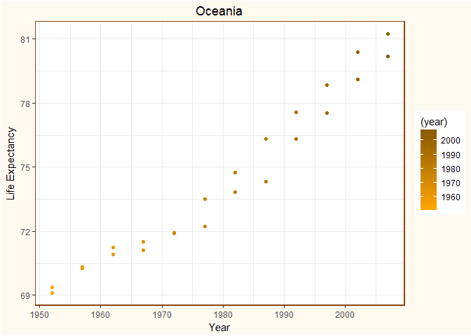

```r
filter(gapminder, continent=="Oceania") %>%
  arrange(year) %>%
  ggplot(aes(lifeExp, year, color=(year))) +
  coord_flip()+
  geom_point()+
  scale_color_gradient(low="orange", high="orange4")+
  labs(title="Oceania", x= "Life Expectancy", y= "Year")+
  theme_bw()+
  theme(plot.background = element_rect(fill = 'floralwhite'),plot.title = element_text(hjust = 0.5), panel.border = element_rect(colour = "chocolate4", fill=NA, size=1))
```

It’s obvious from this graph that there are very few countries from Oceania. Luckily, their life expectancies have been consistently improving.

#### Task 2

Next, I’ll compute a trimmed mean of life expectancy for various years.

From [Investopedia:](http://www.investopedia.com/terms/t/trimmed_mean.asp) “A trimmed mean is a method of averaging that removes a small designated percentage of the largest and smallest values before calculating the mean. After removing the specified observations, the trimmed mean is found using a standard arithmetic averaging formula. The use of a trimmed mean helps eliminate the influence of data points on the tails that may unfairly affect the traditional mean.”

```r
trim_mean<-
mutate(gapminder, trim_mean=mean(lifeExp, trim=0.25))
```

Here, I have added a column of trimmed life expectancy means to the gapminder dataset. But it appears to have failed! I only computed one mean for the entire dataset. What we really want is a trimmed mean by year.

```r
tm<-gapminder %>%
  arrange(year)%>%
  group_by(year) %>%
  summarize(mean(lifeExp, trim=0.25))
names(tm)<-c("year","trimmed_mean")
knitr::kable(tm, format="markdown")
```

| year | trimmed_mean |
| --- | --- |
| 1952 | 47.33607 |
| 1957 | 50.27669 |
| 1962 | 52.79151 |
| 1967 | 55.43138 |
| 1972 | 58.07853 |
| 1977 | 60.46878 |
| 1982 | 62.70044 |
| 1987 | 64.76540 |
| 1992 | 66.19274 |
| 1997 | 67.25389 |
| 2002 | 68.30965 |
| 2007 | 69.68886 |

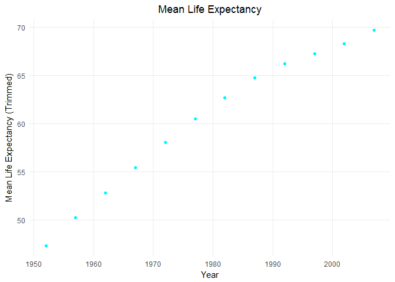

```r
ggplot(tm, aes(year, trimmed_mean))+
  geom_point(color="turquoise1")+
  theme_minimal ()+
  theme(plot.title = element_text(hjust = 0.5), panel.grid.minor = element_blank())+
  labs(title="Mean Life Expectancy", x="Year", y="Mean Life Expectancy (Trimmed)")
```

This plot seems to transition from linear to curvilinear after about 1980. I wonder if the world’s life expectancy will approach a limit some day…

#### Task 3

Let’s look at the GDP per capita spread within the continents.

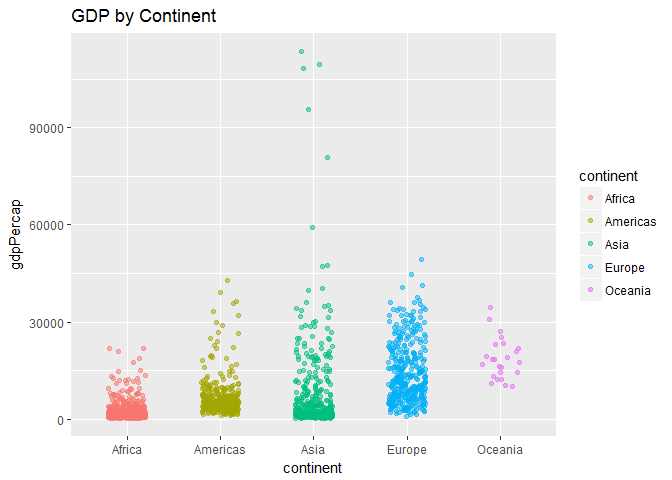

```r
ggplot(gapminder, aes(x=continent, y=gdpPercap))+
  geom_jitter(alpha=.5, aes(color=continent), position=position_jitter(width=.2)) +
  labs(title="GDP by Continent")
```

Here is a snapshot of the world’s GDP per capita in 1972:

```r
c<-select(gapminder, continent, country, year,gdpPercap) %>%
  filter(year%in% c(1972))%>%
  arrange(gdpPercap)
knitr::kable(c, format="markdown")
```

| continent | country | year | gdpPercap |
| --- | --- | --- | --- |
| Asia | Myanmar | 1972 | 357.0000 |
| Asia | Cambodia | 1972 | 421.6240 |
| Africa | Burundi | 1972 | 464.0995 |
| Africa | Lesotho | 1972 | 496.5816 |
| Africa | Eritrea | 1972 | 514.3242 |
| Africa | Ethiopia | 1972 | 566.2439 |
| Africa | Mali | 1972 | 581.3689 |
| Africa | Malawi | 1972 | 584.6220 |
| Africa | Rwanda | 1972 | 590.5807 |
| Asia | Bangladesh | 1972 | 630.2336 |
| Africa | Equatorial Guinea | 1972 | 672.4123 |
| Asia | Nepal | 1972 | 674.7881 |
| Asia | China | 1972 | 676.9001 |
| Asia | Vietnam | 1972 | 699.5016 |
| Asia | India | 1972 | 724.0325 |
| Africa | Mozambique | 1972 | 724.9178 |
| Asia | Afghanistan | 1972 | 739.9811 |
| Africa | Guinea | 1972 | 741.6662 |
| Africa | Gambia | 1972 | 756.0868 |
| Africa | Zimbabwe | 1972 | 799.3622 |
| Africa | Liberia | 1972 | 803.0055 |
| Africa | Guinea-Bissau | 1972 | 820.2246 |
| Africa | Burkina Faso | 1972 | 854.7360 |
| Africa | Congo, Dem. Rep. | 1972 | 904.8961 |
| Africa | Tanzania | 1972 | 915.9851 |
| Africa | Uganda | 1972 | 950.7359 |
| Africa | Niger | 1972 | 954.2092 |
| Asia | Pakistan | 1972 | 1049.9390 |
| Africa | Central African Republic | 1972 | 1070.0133 |
| Africa | Benin | 1972 | 1085.7969 |

[output cut: 112 more lines]

We can tell from that table that, at least for 1972, Kuwait is one of the outliers that makes Asia’s gdpPercap stand out in the graph we printed. This appears to be due to the discovery of oil in Kuwait in 1938 and a relatively small population.

#### Task 4

Now, I’d like to expound on the two countries that stood out the most in the previous tasks. Let’s start with Turkey:

```r
knitr::kable(filter(gapminder, country=="Turkey"),format = "markdown")
```

| country | continent | year | lifeExp | pop | gdpPercap |
| --- | --- | --- | --- | --- | --- |
| Turkey | Europe | 1952 | 43.585 | 22235677 | 1969.101 |
| Turkey | Europe | 1957 | 48.079 | 25670939 | 2218.754 |
| Turkey | Europe | 1962 | 52.098 | 29788695 | 2322.870 |
| Turkey | Europe | 1967 | 54.336 | 33411317 | 2826.356 |
| Turkey | Europe | 1972 | 57.005 | 37492953 | 3450.696 |
| Turkey | Europe | 1977 | 59.507 | 42404033 | 4269.122 |
| Turkey | Europe | 1982 | 61.036 | 47328791 | 4241.356 |
| Turkey | Europe | 1987 | 63.108 | 52881328 | 5089.044 |
| Turkey | Europe | 1992 | 66.146 | 58179144 | 5678.348 |
| Turkey | Europe | 1997 | 68.835 | 63047647 | 6601.430 |
| Turkey | Europe | 2002 | 70.845 | 67308928 | 6508.086 |
| Turkey | Europe | 2007 | 71.777 | 71158647 | 8458.276 |

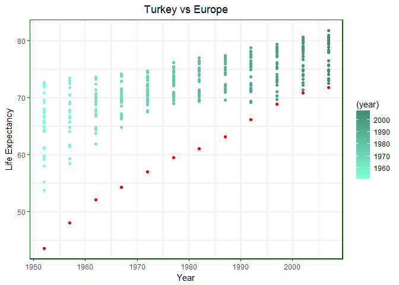

```r
turkey<-    filter(gapminder, country=="Turkey")%>%
  select(year, lifeExp)

europe<-filter(gapminder, continent=="Europe") %>%
  arrange(year) %>%
  ggplot(aes(lifeExp, year, color=(year))) +
  coord_flip()+
  geom_point()+
 geom_point(data = turkey, colour = "red")+
  scale_color_gradient(low="aquamarine", high="aquamarine4")+
  labs(title="Turkey vs Europe", x= "Life Expectancy", y= "Year")+
  theme_bw()+
  theme(plot.title = element_text(hjust = 0.5), panel.border = element_rect(colour = "darkgreen", fill=NA, size=1))
europe
```

Here, I have shown Turkey (red) against a backdrop of the rest of Europe. Clearly, Turkey was going through something during this time. After some [research](https://en.wikipedia.org/wiki/Timeline_of_the_Republic_of_Turkey) I found that Turkey participated in the Korean war from 1950-1953. Turkey’s timeline displays a series of military coups, tension between church and state, and general civil unrest. This is in addition to having astronomical inflation rates historically. Turkey’s life expectancy trails behind the rest of Europe even today.

```r
cambodia<-filter(gapminder, country=="Cambodia")
knitr::kable(cambodia, format = "markdown")
```

| country | continent | year | lifeExp | pop | gdpPercap |
| --- | --- | --- | --- | --- | --- |
| Cambodia | Asia | 1952 | 39.417 | 4693836 | 368.4693 |
| Cambodia | Asia | 1957 | 41.366 | 5322536 | 434.0383 |
| Cambodia | Asia | 1962 | 43.415 | 6083619 | 496.9136 |
| Cambodia | Asia | 1967 | 45.415 | 6960067 | 523.4323 |
| Cambodia | Asia | 1972 | 40.317 | 7450606 | 421.6240 |
| Cambodia | Asia | 1977 | 31.220 | 6978607 | 524.9722 |
| Cambodia | Asia | 1982 | 50.957 | 7272485 | 624.4755 |
| Cambodia | Asia | 1987 | 53.914 | 8371791 | 683.8956 |
| Cambodia | Asia | 1992 | 55.803 | 10150094 | 682.3032 |
| Cambodia | Asia | 1997 | 56.534 | 11782962 | 734.2852 |
| Cambodia | Asia | 2002 | 56.752 | 12926707 | 896.2260 |
| Cambodia | Asia | 2007 | 59.723 | 14131858 | 1713.7787 |

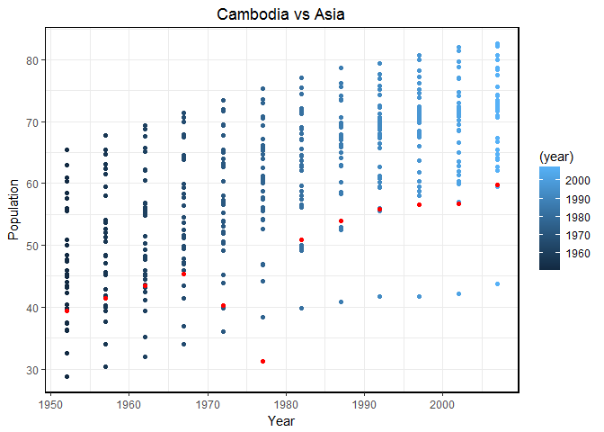

```r
filter(gapminder, continent=="Asia") %>%
  arrange(year) %>%
  ggplot(aes(lifeExp, year, color=(year))) +
  coord_flip()+
  geom_point()+
 geom_point(data = cambodia, colour = "red")+
  labs(title="Cambodia vs Asia", x= "Population", y= "Year")+
  theme_bw()+
  theme(plot.title = element_text(hjust = 0.5), panel.border = element_rect(colour = "black", fill=NA, size=1))
```

### Process

This homework was more intimidating than the previous homeworks. There was a lot more freedom.

Once I got started, I definitely got carried away with my exploration of the dataset and the plotting options offered by ggplot2

I used stack overflow quite a bit to learn the plotting functions I needed. Every time I use ggplot2 I come across some new feature that I want to use.